# Estudiante : Gustavo Guallpa

A continuacion se ejemplifica la busqueda por costo revisada en clase. Para ello se tiene un ejemplo de las ciudades del territorio Ecuatoriano y su distancia.

```python
# Busqueda por costo.

# Creamos la clase Nodo
class Node:
    def __init__(self, data, child=None): # Constructor de la clase
        self.data = data
        self.child = None
        self.fathr = None
        self.cost = None # Importante tener el costo de recorer el nodo
        self.set_child(child)

    def set_child(self, child): # Agregar hijos
        self.child = child
        if self.child is not None:
            for ch in self.child:
                ch.fathr = self

    def equal(self, node):
        if self.data == node.data:
            return True
        else:
            return False

    def on_list(self, node_list): # Verfiicar su el nodo esta en la lista
        listed = False
        for n in node_list:
            if self.equal(n):
                listed = True
        return listed

    def __str__(self): # Igual al toString Java
        return str(self.data)
```

```python
#Definimos una funcion para obtener el costo - CompareTo (Java)
def Compare(node):
    return node.cost
```

```python
# Implementacion del metodo de busqueda por costo
def search_costo_solucion(connections, init_state, solution):
    solved = False # Variable para almacenar el estado de la busqueda
    visited_nodes = [] # Nodos visitados
    frontier_nodes = [] # Nodos en busqueda o lista nodos o nodos por visitar

    init_node = Node(init_state) # Nodo inicial
    init_node.cost =0 # Agregar costo inicial
    frontier_nodes.append(init_node)
    while (not solved) and len(frontier_nodes) != 0:
        frontier_nodes = sorted(frontier_nodes, key=Compare) # Ordenar lista de nodos
        node = frontier_nodes[0]
        visited_nodes.append(frontier_nodes.pop(0)) # Extraer nodo y añadirlo a visitados
        if node.data == solution:# Solucion encontrada
            solved = True
            return node
        else:
            node_data = node.data# Expandir nodos hijo (ciudades con conexion)
            child_list = []
            for achild in connections[node_data]: # Recorrera cada uno de los nodos hijos
                child = Node(achild)
                cost = connections[node_data][achild] # Obtener el costo del nodo
                child.cost = node.cost + cost # Agregamos el costo actual del nodo + el historial
                child_list.append(child)
                if not child.on_list(visited_nodes):
                    if child.on_list(frontier_nodes): # Si está en la lista lo sustituimos con el nuevo valor de coste si es menor
                        for n in frontier_nodes:
                            if n.equal(child) and n.cost > child.cost:
                                frontier_nodes.remove(n)
                                frontier_nodes.append(child)
                    else:
                        frontier_nodes.append(child)
            node.set_child(child_list)

if __name__ == "__main__":
    connections = {
        'Cuenca': {'Riobamba':190, 'Quito':280, 'Guayaquil':170},
        'Latacunga': {'Ambato':50, 'Quito':30},
        'Esmeraldas': {'Manta':80},
        'Manta': {'Guayaquil':60},
        'Quito': {'Riobamba':110, 'Latacunga':30, 'Cuenca':280, 'Guayaquil':190, 'Puyo':170},
        'Riobamba': {'Cuenca':190, 'Quito':110},
        'Ambato': {'Latacunga':50, 'Puyo':80, 'Guayaquil':230},
        'Puyo': {'Ambato':60, 'Quito':170},
        'Machala': {'Guayaquil':80},
        'Guayaquil': {'Machala':80, 'Ambato':230, 'Quito':190, 'Cuenca':170, 'Manta':60}
    }

    init_state = 'Cuenca'
    solution = 'Quito'
    solution_node = search_costo_solucion(connections, init_state, solution)
    # mostrar resultado
    result = []
    node = solution_node
    if node is not None:
        while node.fathr is not None:
            result.append(node.data)
            node = node.fathr
        result.append(init_state)
        result.reverse() # Reverso el resultado (Solo para presentar)
        print(result)
        resultadoCiudades = result
        print("Costo total: %s" % str(solution_node.cost)) # Imprimir el costo total de llegar al nodo
    else:
        print("No hay solucion !!!!")
```

```
['Cuenca', 'Quito']
Costo total: 280
```

## Practica

Implementar un algoritmo que me permita dibujar las conexiones con los costos y los resultados del grafo.

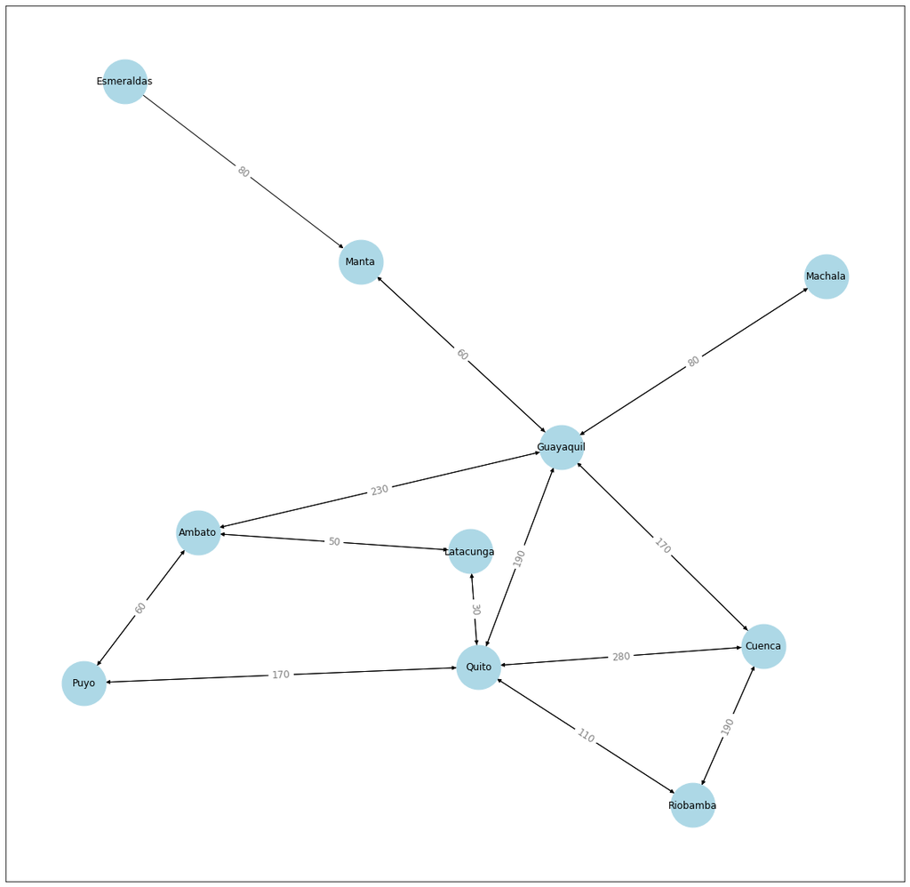

```python
###Dibujo de la conexiones con cada uno de sus costos.
#Importamos las librerías a utilizar
import networkx as nx
import numpy as np
import matplotlib.pyplot as plt

#Se crea una funcion para dibujar las conexiones.
def dibujarConexiones(lista):
    graf = nx.DiGraph()
    graf.add_nodes_from(lista)
    for valor, listaValor in lista.items():
        for a in listaValor:
            graf.add_edge(valor, a, size=250, length=str(listaValor[a]))

    pos = nx.spring_layout(graf)
    plt.figure(figsize=(20, 20))
    #Para que nos muestre cada uno de los costos de cada ruta
    labels = nx.get_edge_attributes(graf, 'length')
    nx.draw_networkx(graf, pos, node_color='lightblue', with_labels=True, node_size=3000)
    nx.draw_networkx_edge_labels(graf, pos, edge_labels=labels, font_color='gray', font_size=12)
    #Mostramos los resultados
    plt.show()

#Llamamos a nuestro método
dibujarConexiones(connections)
```

```
Costo total: 280
```

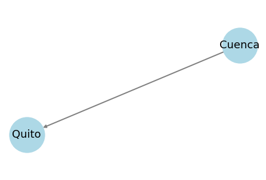

```python
#**********DIBUJO DE LA SOLUCION**********#
#Importacion de la librerias necesarias
import csv
from os import remove
# Networkx para grafos
import networkx as nx
# Pandas
import pandas as pd


lista1 = []
lista1.append('origin')
lista1.append('destination')

def escribriDatos1():
    file = open("solCiudades.csv", "a")
    spamreader = csv.writer(file)
    spamreader.writerow(lista1)
    file.close()

escribriDatos1()

#Metoddo para ecribir los datos en un archivo
def escribriDatos(lista):
    file = open("solCiudades.csv", "a")
    spamreader = csv.writer(file)
    spamreader.writerow(lista)
    file.close()


lista_nueva = []
x = 0
cont = 0
while x < len(resultadoCiudades):
    if cont != 2:
        lista_nueva.append(result[x])
        cont = cont + 1

    if cont == 2:
        escribriDatos(lista_nueva)
        cont = 0
        lista_nueva = []
        x = x -1

    x = x + 1

sol_lista = pd.read_csv("solCiudades.csv")
DG=nx.DiGraph()
for row in sol_lista.iterrows():
    DG.add_edge(row[1]["origin"],
                row[1]["destination"])

nx.draw_spring(DG,
                 node_color="lightblue",
                 edge_color="gray",
                 font_size=18,
                 width=2, with_labels=True, node_size=3500,
)

remove("solCiudades.csv")
print("Costo total: %s" % str(solution_node.cost))
```

Mediante el uso de la herramienta de Google Maps tomar al su direccion domiciliaria como punto de partida y generar un arbol jerarquico con todos los posibles Policia/UPC/Funcion Judicial, para ello se debe tener como primer nivel los mas cercanos y a continuacion los demas generando un arbol jerarquico

```python
# Creamos la clase Nodo
class Node:
    def __init__(self, data, child=None): # Constructor de la clase
        self.data = data
        self.child = None
        self.fathr = None
        self.cost = None # Importante tener el costo de recorer el nodo
        self.set_child(child)

    def set_child(self, child): # Agregar hijos
        self.child = child
        if self.child is not None:
            for ch in self.child:
                ch.fathr = self

    def equal(self, node):
        if self.data == node.data:
            return True
        else:
            return False

    def on_list(self, node_list): # Verfiicar su el nodo esta en la lista
        listed = False
        for n in node_list:
            if self.equal(n):
                listed = True
        return listed

    def __str__(self): # Igual al toString Java
        return str(self.data)

#Definimos una funcion para obtener el costo - CompareTo (Java)
def Compare(node):
    return node.cost

# Implementacion del metodo de busqueda por costo
def search_costo_solucion(connections, init_state, solution):
    solved = False # Variable para almacenar el estado de la busqueda
    visited_nodes = [] # Nodos visitados
    frontier_nodes = [] # Nodos en busqueda o lista nodos o nodos por visitar

    init_node = Node(init_state) # Nodo inicial
    init_node.cost =0 # Agregar costo inicial
    frontier_nodes.append(init_node)
    while (not solved) and len(frontier_nodes) != 0:
        frontier_nodes = sorted(frontier_nodes, key=Compare) # Ordenar lista de nodos
        node = frontier_nodes[0]
        visited_nodes.append(frontier_nodes.pop(0)) # Extraer nodo y añadirlo a visitados
        if node.data == solution:# Solucion encontrada
            solved = True
            return node
        else:
            node_data = node.data# Expandir nodos hijo (ciudades con conexion)
            child_list = []
            for achild in connections[node_data]: # Recorrera cada uno de los nodos hijos
                child = Node(achild)
                cost = connections[node_data][achild] # Obtener el costo del nodo
                child.cost = node.cost + cost # Agregamos el costo actual del nodo + el historial
                child_list.append(child)
                if not child.on_list(visited_nodes):
                    if child.on_list(frontier_nodes): # Si está en la lista lo sustituimos con el nuevo valor de coste si es menor
                        for n in frontier_nodes:
                            if n.equal(child) and n.cost > child.cost:
                                frontier_nodes.remove(n)
                                frontier_nodes.append(child)
                    else:
                        frontier_nodes.append(child)
            node.set_child(child_list)

if __name__ == "__main__":
    connections = {
        'Casa': {'Departamento de UPC':1.2, 'Policia de Narcoticos':1.4, 'Unidad de Policia Comunitaria':4.5},
        'Departamento de UPC': {'Casa':1.2 },
        'Policia de Narcoticos': {'Policia Nacional':3.4,'Casa':1.2},

        'Policia Nacional': {'Policia Nacional el Sagrario':1.2,'Policia Nacional Zona 6':0.5,'Subzona de Policia Azuay No 1':2.5,'Intendencia General de Policia del Azuay':1.4,'Policia de Narcoticos':3.4},


        'Policia Nacional el Sagrario': {'UPC Terminal Terrestre':1.04,'UPC Tororacocha':2.14,'Policia Nacional':1.2},
        'UPC Terminal Terrestre': {'Policia Nacional el Sagrario':1.04},
        'UPC Tororacocha': {'Policia Nacional el Sagrario':2.14},
        'Policia Nacional Zona 6': {'Policia Nacional':0.5},


        'Subzona de Policia Azuay No 1': {'Policia Judicial del Azuay':1.15, 'Policia Municipal Guardia Ciudadana':2.2, 'UPC Miraflores':1.06,'Policia Nacional':2.5},
        'Policia Judicial del Azuay': {'UPC El Paraiso':2,'UPC de Policia Tomebamba':4,'Subzona de Policia Azuay No 1':1.15},
        'UPC El Paraiso': {'Policia Judicial del Azuay':2},
        'UPC de Policia Tomebamba': {'Policia Judicial del Azuay':4},


        'Policia Municipal Guardia Ciudadana': {'Guarda Ciudadana de Cuenca':2.35,'Subzona de Policia Azuay No 1':2.2},
        'Guarda Ciudadana de Cuenca': {'Policia Municipal Guardia Ciudadana':2.35},


        'UPC Miraflores': {'Subzona de Policia Azuay No 1':1.06},


        'Intendencia General de Policia del Azuay': {'Policia Nacional':1.4},

        'Unidad de Policia Comunitaria': {'Casa':4.5},

    }

    init_state = 'Casa'
    solution = 'UPC Miraflores'
    solution_node = search_costo_solucion(connections, init_state, solution)
    # mostrar resultado
    result = []
    node = solution_node
    if node is not None:
        while node.fathr is not None:
            result.append(node.data)
            node = node.fathr
        result.append(init_state)
        result.reverse() # Reverso el resultado (Solo para presentar)
        print(result)
        resultadoPolicias = result
        print("Costo total: %s" % str(solution_node.cost)) # Imprimir el costo total de llegar al nodo
    else:
        print("No hay solucion !!!!")
```

```
['Casa', 'Policia de Narcoticos', 'Policia Nacional', 'Subzona de Policia Azuay No 1', 'UPC Miraflores']
Costo total: 8.36
```

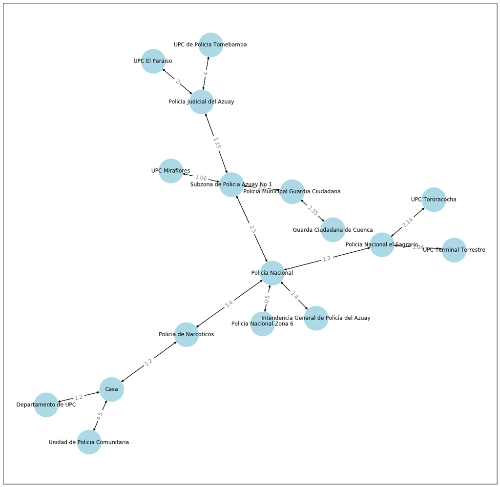

```python
###Dibujo de la conexiones con cada uno de sus costos.
#Importamos las librerías a utilizar
import networkx as nx
import numpy as np
import matplotlib.pyplot as plt

#Se crea una funcion para dibujar las conexiones.
def dibujarConexiones(lista):
    graf = nx.DiGraph()
    graf.add_nodes_from(lista)
    for valor, listaValor in lista.items():
        for a in listaValor:
            graf.add_edge(valor, a, size=250, length=str(listaValor[a]))

    pos = nx.spring_layout(graf)
    plt.figure(figsize=(20, 20))
    #Para que nos muestre cada uno de los costos de cada ruta
    labels = nx.get_edge_attributes(graf, 'length')
    nx.draw_networkx(graf, pos, node_color='lightblue', with_labels=True, node_size=3000)
    nx.draw_networkx_edge_labels(graf, pos, edge_labels=labels, font_color='gray', font_size=12)
    #Mostramos los resultados
    plt.show()

#Llamamos a nuestro método
dibujarConexiones(connections)
```

```
Costo total: 8.36
```

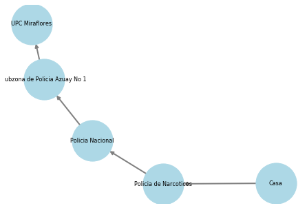

```python
#**********DIBUJO DE LA SOLUCION**********#
#Importacion de la librerias necesarias
import csv
from os import remove
# Networkx para grafos
import networkx as nx
# Pandas
import pandas as pd


lista1 = []
lista1.append('origin')
lista1.append('destination')

def escribriDatos1():
    file = open("solPolicias.csv", "a")
    spamreader = csv.writer(file)
    spamreader.writerow(lista1)
    file.close()

escribriDatos1()

#Metoddo para ecribir los datos en un archivo
def escribriDatos(lista):
    file = open("solPolicias.csv", "a")
    spamreader = csv.writer(file)
    spamreader.writerow(lista)
    file.close()


lista_nueva = []
x = 0
cont = 0
while x < len(resultadoPolicias):
    if cont != 2:
        lista_nueva.append(result[x])
        cont = cont + 1

    if cont == 2:
        escribriDatos(lista_nueva)
        cont = 0
        lista_nueva = []
        x = x -1

    x = x + 1

sol_lista = pd.read_csv("solPolicias.csv")
DG=nx.DiGraph()
for row in sol_lista.iterrows():
    DG.add_edge(row[1]["origin"],
                row[1]["destination"])

nx.draw_spring(DG,
                 node_color="lightblue",
                 edge_color="gray",
                 font_size=8,
                 width=2, with_labels=True, node_size=3500,
)

remove("solPolicias.csv")
print("Costo total: %s" % str(solution_node.cost))
```

Realizar los calculos para obtener el factor de ramificacion, análisis del algoritmo en términos de completitud, optimalidad, complejidad temporal y complejidad espacial.

### Factor de ramificación

*Datos*

N= 17

# Profundidad

d= 5

# Factor de ramificación

b= ?

*Fórmula*

b = NodosTotales / d

b = 17 / 5

*b = 3.4*

### Completitud

El algoritmo es completo, ya que encontrará la solución siempre y cuando se cuenten con los recursos necesarios (memoria y procesamiento).

### Optimalidad

Es óptimo ya que devuelve la solución con menor coste.

### Complejidad Temporal

*Dependerá del factor de ramificación y de la profundidad del árbol. El coste temporal es O(b^n), donde b es el factor de ramificación y profundidad del árbol es n.*

n=d=profundidad

O(b^n)

O = 3.4^5

O = 454,35

### Complejidad Espacial

n=profundidad

b=factor de ramificación

O(n*b)

O = 5 * 3.4 =17

Generar un arbol de expansion del COVID-19 en el Ecuador y agregarle al metodo de costo para obtener la ruta de contagio.

```python
# Creamos la clase Nodo
class Node:
    def __init__(self, data, child=None): # Constructor de la clase
        self.data = data
        self.child = None
        self.fathr = None
        self.cost = None # Importante tener el costo de recorer el nodo
        self.set_child(child)

    def set_child(self, child): # Agregar hijos
        self.child = child
        if self.child is not None:
            for ch in self.child:
                ch.fathr = self

    def equal(self, node):
        if self.data == node.data:
            return True
        else:
            return False

    def on_list(self, node_list): # Verfiicar su el nodo esta en la lista
        listed = False
        for n in node_list:
            if self.equal(n):
                listed = True
        return listed

    def __str__(self): # Igual al toString Java
        return str(self.data)

#Definimos una funcion para obtener el costo - CompareTo (Java)
def Compare(node):
    return node.cost

# Implementacion del metodo de busqueda por costo
def search_costo_solucion(connections, init_state, solution):
    solved = False # Variable para almacenar el estado de la busqueda
    visited_nodes = [] # Nodos visitados
    frontier_nodes = [] # Nodos en busqueda o lista nodos o nodos por visitar

    init_node = Node(init_state) # Nodo inicial
    init_node.cost =0 # Agregar costo inicial
    frontier_nodes.append(init_node)
    while (not solved) and len(frontier_nodes) != 0:
        frontier_nodes = sorted(frontier_nodes, key=Compare) # Ordenar lista de nodos
        node = frontier_nodes[0]
        visited_nodes.append(frontier_nodes.pop(0)) # Extraer nodo y añadirlo a visitados
        if node.data == solution:# Solucion encontrada
            solved = True
            return node
        else:
            node_data = node.data# Expandir nodos hijo (ciudades con conexion)
            child_list = []
            for achild in connections[node_data]: # Recorrera cada uno de los nodos hijos
                child = Node(achild)
                cost = connections[node_data][achild] # Obtener el costo del nodo
                child.cost = node.cost + cost # Agregamos el costo actual del nodo + el historial
                child_list.append(child)
                if not child.on_list(visited_nodes):
                    if child.on_list(frontier_nodes): # Si está en la lista lo sustituimos con el nuevo valor de coste si es menor
                        for n in frontier_nodes:
                            if n.equal(child) and n.cost > child.cost:
                                frontier_nodes.remove(n)
                                frontier_nodes.append(child)
                    else:
                        frontier_nodes.append(child)
            node.set_child(child_list)

if __name__ == "__main__":
    connectionsc = {
        'Los Rios': {'Bolivar':33, 'Cotopaxi':45, 'Manabi':227, 'Pichincha':674, 'Guayas':5551},
        'Bolivar': {'Los Rios': 255},
        'Cotopaxi': {'Los Rios': 255},
        'Manabi':{'Esmeraldas':44, 'Santo Domingo':67, 'Los Rios':255},
        'Esmeraldas':{'Manabi':227},
        'Santo Domingo':{'Manabi':227},

        'Pichincha':{'Sucumbios':33, 'Imbabura':34 ,'Los Rios':255},
        'Sucumbios':{'Orellana':6,'Pichincha':674},
        'Orellana':{'Sucumbios':33},
        'Imbabura':{'Carchi':26, 'Pichincha':674},
        'Carchi':{'Imbabura':34},

        'Azuay':{'Canar':105, 'Zamora Chinchipe':5, 'El Oro':183},
        'Canar':{'Chimborazo':90, 'Azuay':200},
        'Chimborazo':{'Tungurahua':47, 'Canar':105},
        'Tungurahua':{'Chimborazo':90},
        'Zamora Chinchipe':{'Azuay':200},

        'Guayas':{'Napo':8, 'Pastaza':16, 'Galapagos':11, 'Santa Elena':92, 'Morona Santiago':21, 'Loja':85, 'El Oro':183, 'Los Rios':255},
        'Napo':{'Guayas':5551},
        'Pastaza':{'Guayas':5551},
        'Galapagos':{'Guayas':5551},
        'Santa Elena':{'Guayas':5551},
        'Morona Santiago':{'Guayas':5551},
        'Loja':{'Guayas':5551},
        'El Oro':{'Azuay':200, 'Guayas':5551}



    }

    init_state = 'Los Rios'
    #Ingrese la ciudad de la que desea conconer el numero de contagiados, en los resultados no se incluye
    #la cantidad de casos de el estado incial
    solution = 'Morona Santiago'
    solution_node = search_costo_solucion(connectionsc, init_state, solution)
    # mostrar resultado
    result = []
    node = solution_node
    if node is not None:
        while node.fathr is not None:
            result.append(node.data)
            node = node.fathr
        result.append(init_state)
        result.reverse() # Reverso el resultado (Solo para presentar)
        print(result)
        resultadoCovid = result
        print("Costo total: %s" % str(solution_node.cost)) # Imprimir el costo total de llegar al nodo
    else:
        print("No hay solucion !!!!")
```

```
['Los Rios', 'Guayas', 'Morona Santiago']
Costo total: 5572
```

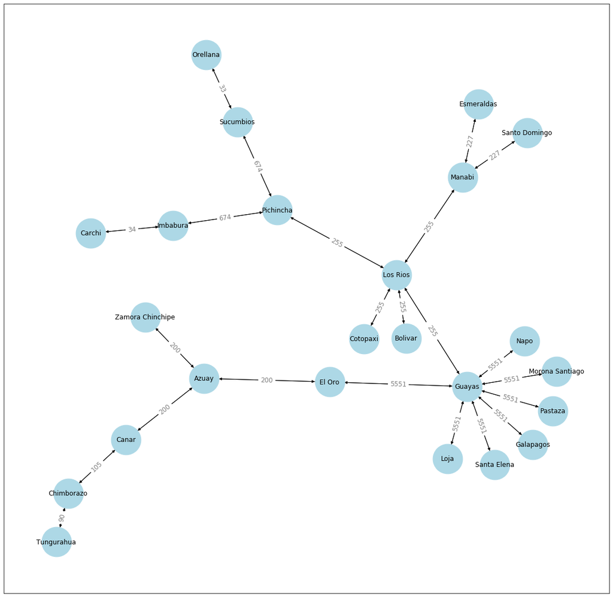

```python
#Dibujo de la expansion
###Dibujo de la conexiones con cada uno de sus costos.
#Importamos las librerías a utilizar
import networkx as nx
import numpy as np
import matplotlib.pyplot as plt

#Se crea una funcion para dibujar las conexiones.
def dibujarConexiones(lista):
    graf = nx.DiGraph()
    graf.add_nodes_from(lista)
    for valor, listaValor in lista.items():
        for a in listaValor:
            graf.add_edge(valor, a, size=250, length=str(listaValor[a]))

    pos = nx.spring_layout(graf)
    plt.figure(figsize=(20, 20))
    #Para que nos muestre cada uno de los costos de cada ruta
    labels = nx.get_edge_attributes(graf, 'length')
    nx.draw_networkx(graf, pos, node_color='lightblue', with_labels=True, node_size=3000)
    nx.draw_networkx_edge_labels(graf, pos, edge_labels=labels, font_color='gray', font_size=12)
    #Mostramos los resultados
    plt.show()

#Llamamos a nuestro método
dibujarConexiones(connectionsc)
```

```
Costo total: 5572
```

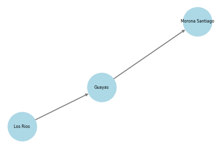

```python
#**********DIBUJO DE LA SOLUCION**********#
#Importacion de la librerias necesarias
import csv
from os import remove
# Networkx para grafos
import networkx as nx
# Pandas
import pandas as pd


lista1 = []
lista1.append('origin')
lista1.append('destination')

def escribriDatos1():
    file = open("solCov.csv", "a")
    spamreader = csv.writer(file)
    spamreader.writerow(lista1)
    file.close()

escribriDatos1()

#Metoddo para ecribir los datos en un archivo
def escribriDatos(lista):
    file = open("solCov.csv", "a")
    spamreader = csv.writer(file)
    spamreader.writerow(lista)
    file.close()


lista_nueva = []
x = 0
cont = 0
while x < len(resultadoCovid):
    if cont != 2:
        lista_nueva.append(result[x])
        cont = cont + 1

    if cont == 2:
        escribriDatos(lista_nueva)
        cont = 0
        lista_nueva = []
        x = x -1

    x = x + 1

sol_lista = pd.read_csv("solCov.csv")
DG=nx.DiGraph()
for row in sol_lista.iterrows():
    DG.add_edge(row[1]["origin"],
                row[1]["destination"])

nx.draw_spring(DG,
                 node_color="lightblue",
                 edge_color="gray",
                 font_size=8,
                 width=2, with_labels=True, node_size=3500,
)

remove("solCov.csv")
print("Costo total: %s" % str(solution_node.cost))
```

Subir el cuaderno con la resolucion

# Conclusiones

De manera general podemos evidenciar que este algortimo de busquedas, es mas eficiente cuanto a las busquedas , ya que gracias al costos el algoritmo puede realizar las busquedas de una forma más rápida.